# Assignment 4

Trang Thuy Nguyen ID29091985

October 23, 2020

# Question 1

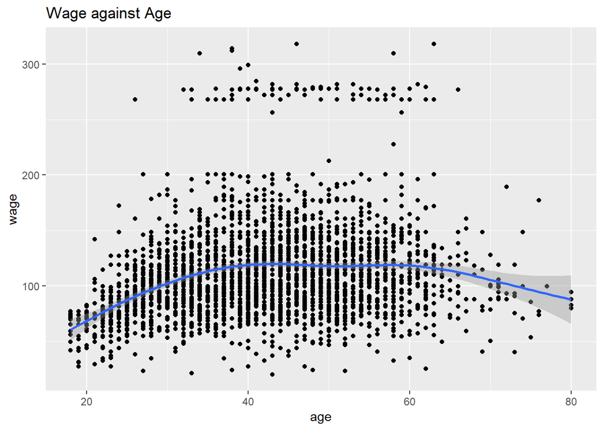

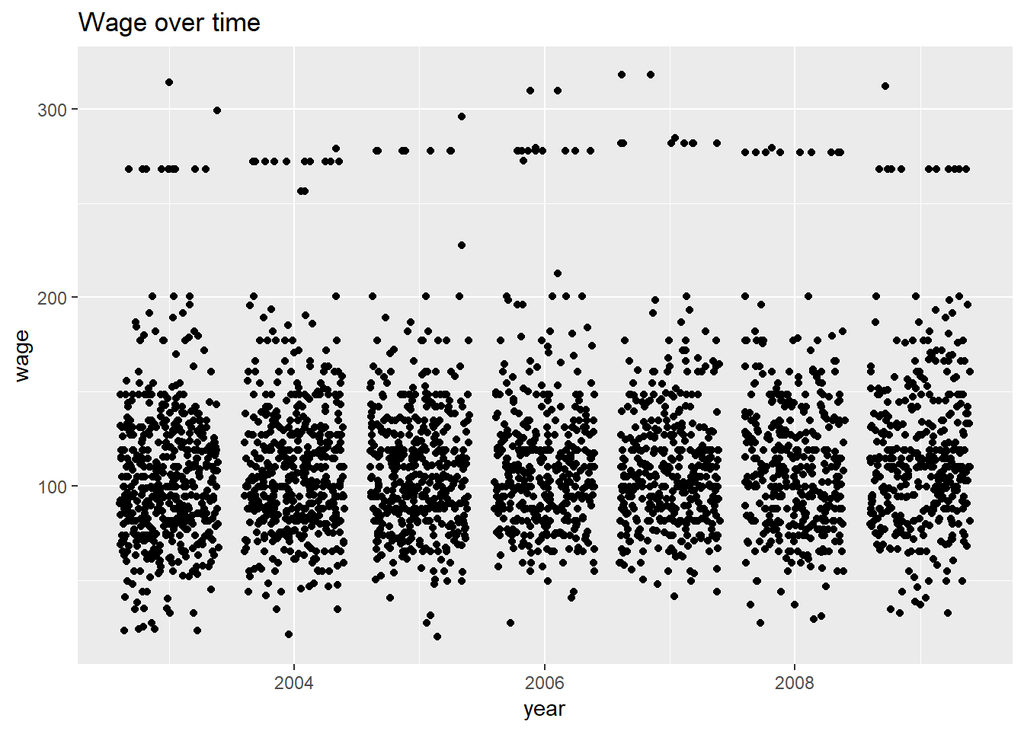

There is no clear pattern in the relationship between **wage** and **year**.

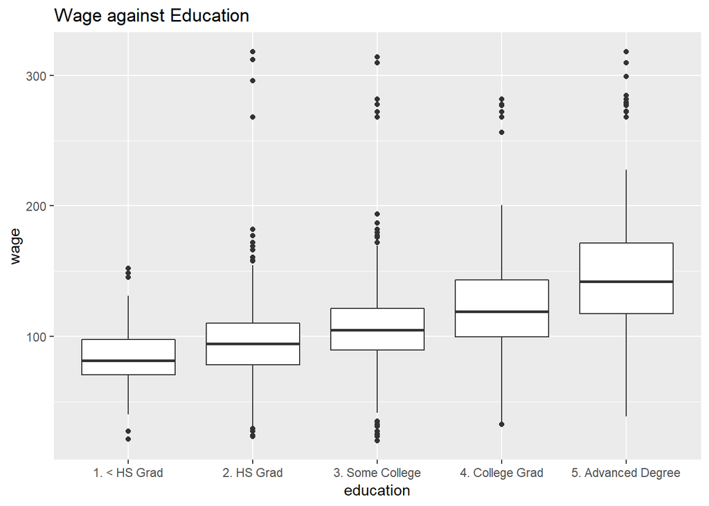

From this boxplot, we can defenitely observe that as the educatiton level of a worker is higher, their wages also rise up. In other words, **wage** and **education** have positive correlation.

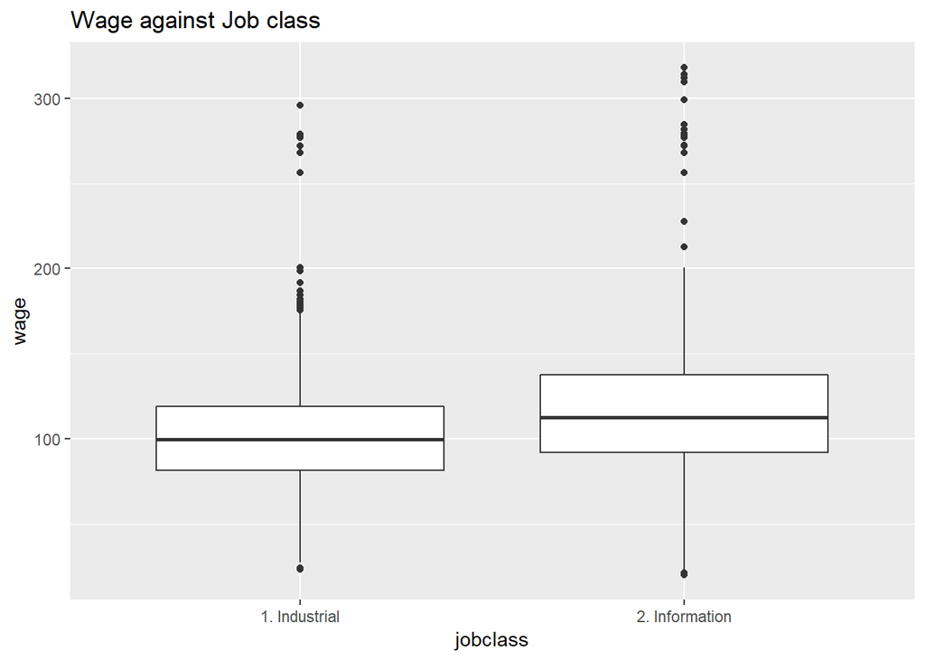

It seems that if the **job class** of a worker is *Information*, then his wage tends to be higher than a worker whose job class is *Industrial*.

# Question 2

```
##
## Family: gaussian
## Link function: identity
##
## Formula:
## wage ~ age + year + education + jobclass
##
## Parametric coefficients:
##                              Estimate Std. Error t value Pr(>|t|)
## (Intercept)                 -2.09e+03   6.48e+02   -3.22  0.00129 **
## age                          5.48e-01   5.72e-02    9.59  < 2e-16 ***
## year                         1.07e+00   3.23e-01    3.31  0.00093 ***
## education2. HS Grad          1.12e+01   2.47e+00    4.51  6.7e-06 ***
## education3. Some College     2.34e+01   2.61e+00    8.95  < 2e-16 ***
## education4. College Grad     3.83e+01   2.62e+00   14.66  < 2e-16 ***
## education5. Advanced Degree  6.27e+01   2.87e+00   21.86  < 2e-16 ***
## jobclass2. Information       4.57e+00   1.38e+00    3.32  0.00092 ***
## ---
## Signif. codes:  0 '***' 0 '**' 0 '*' 0 '.' 0 ' ' 1
##
##
## R-sq.(adj) =  0.263   Deviance explained = 26.5%
## GCV = 1286.9  Scale est. = 1283.5    n = 3000
```

- On average, a **20-year-old** worker earns 11 thousands of dollars, holding all other things constant
- On average, a **60-year-old** worker earns 33 thousands of dollars, holdind all other things constant
- So on average, the worker of 20 years old earns 22 thousands of dollars less than the worker of 60 years old, holding all other things constant

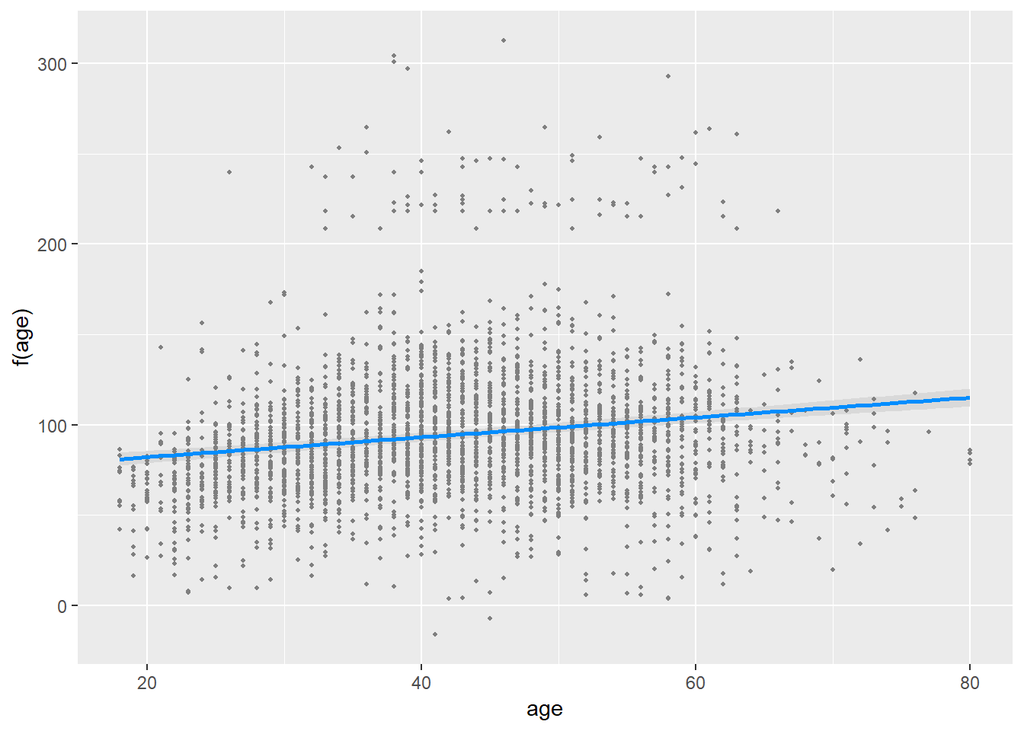

The plot shows that as people get older, they would earn more. The reason might be because they have more experience so they get promotion, or they change to other higher wage job.

# Question 3

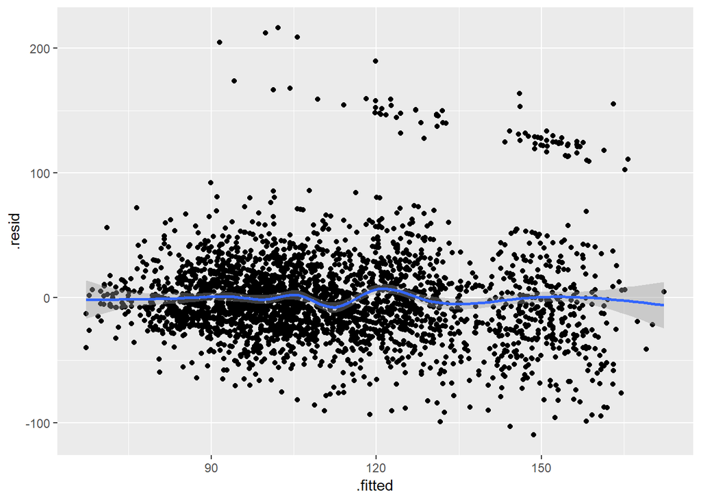

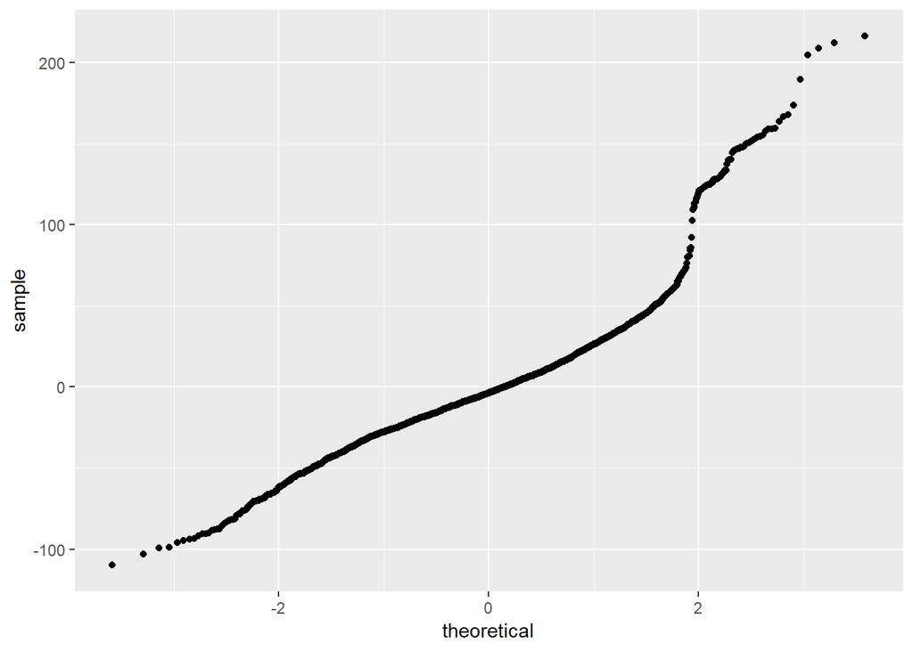

The QQ plot shows that the line bended and not exactly or near 45 degree line so there exists non-linearity. The residuals and fitted values plot also shows some heteroskedasticity and skewness.

We may take the log transformation to make the pattern more interpretable.

```
##
## Family: gaussian
## Link function: identity
##
## Formula:
## log(wage) ~ age + year + education + jobclass
##
## Parametric coefficients:
##                              Estimate Std. Error t value Pr(>|t|)
## (Intercept)                 -1.77e+01   5.46e+00   -3.24   0.0012 **
## age                          5.40e-03   4.82e-04   11.20  < 2e-16 ***
## year                         1.09e-02   2.72e-03    4.00  6.4e-05 ***
## education2. HS Grad          1.18e-01   2.08e-02    5.67  1.5e-08 ***
## education3. Some College     2.37e-01   2.20e-02   10.76  < 2e-16 ***
## education4. College Grad     3.56e-01   2.20e-02   16.17  < 2e-16 ***
## education5. Advanced Degree  5.24e-01   2.42e-02   21.65  < 2e-16 ***
## jobclass2. Information       3.81e-02   1.16e-02    3.28   0.0010 **
## ---
## Signif. codes:  0 '***' 0 '**' 0 '*' 0 '.' 0 ' ' 1
##
##
## R-sq.(adj) =  0.264   Deviance explained = 26.6%
## GCV = 0.091307  Scale est. = 0.091064  n = 3000
```

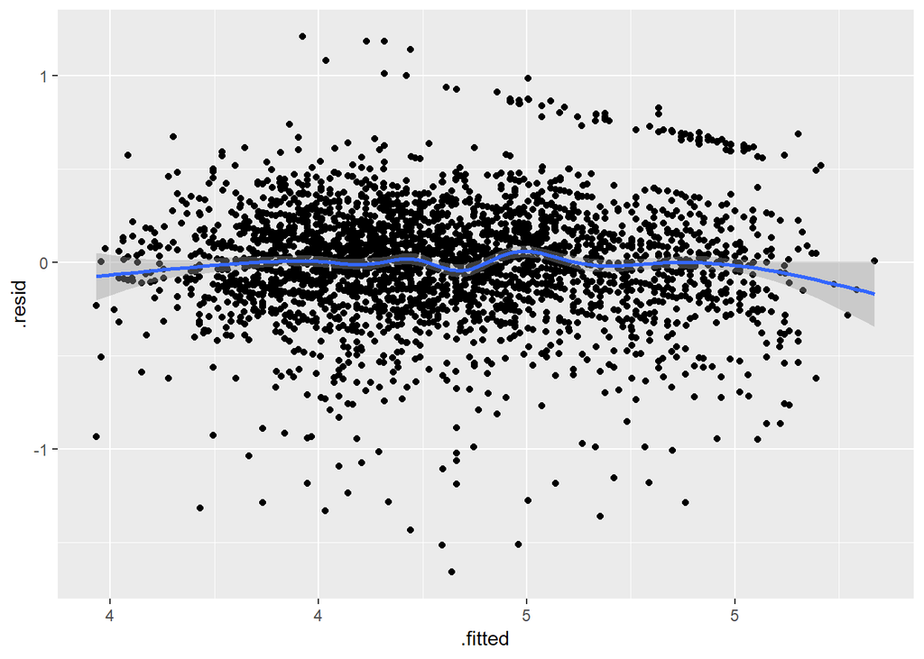

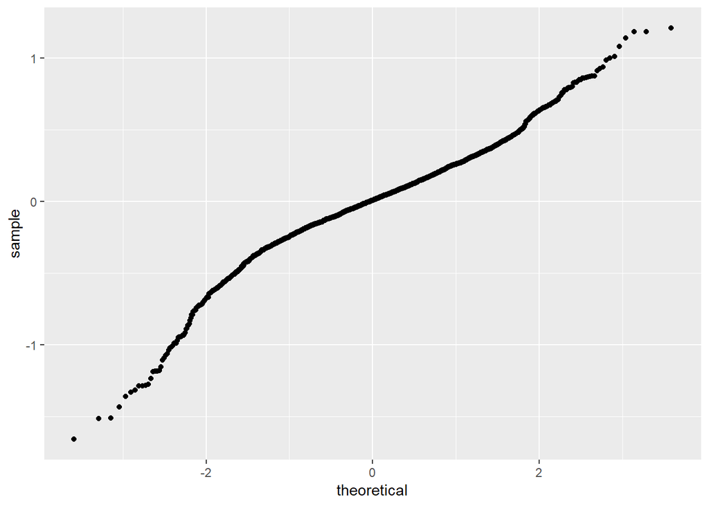

The QQ plot now is more near to 45 degree line. The residuals and fitted values plot is also less heterokedasticity. It looks better than before but non-linearity is still not captured well by the model. We will need more complex model to deal with this.

# Question 4

```
##
## Family: gaussian
## Link function: identity
##
## Formula:
## log(wage) ~ s(age, k = 20, fx = TRUE) + s(year, k = 4, fx = TRUE) +
##     education + jobclass
##
## Parametric coefficients:
##                             Estimate Std. Error t value Pr(>|t|)
## (Intercept)                   4.4048     0.0183  240.30  < 2e-16 ***
## education2. HS Grad           0.1117     0.0203    5.49  4.3e-08 ***
## education3. Some College      0.2247     0.0215   10.43  < 2e-16 ***
## education4. College Grad      0.3360     0.0215   15.60  < 2e-16 ***
## education5. Advanced Degree   0.4967     0.0236   21.03  < 2e-16 ***
## jobclass2. Information        0.0352     0.0113    3.11   0.0019 **
## ---
## Signif. codes:  0 '***' 0 '**' 0 '*' 0 '.' 0 ' ' 1
##
## Approximate significance of smooth terms:
##         edf Ref.df     F p-value
## s(age)   19     19 18.08 < 2e-16 ***
## s(year)   3      3  8.54 1.2e-05 ***
## ---
## Signif. codes:  0 '***' 0 '**' 0 '*' 0 '.' 0 ' ' 1
##
## R-sq.(adj) =  0.309   Deviance explained = 31.5%
## -REML = 628.88  Scale est. = 0.085513  n = 3000
```

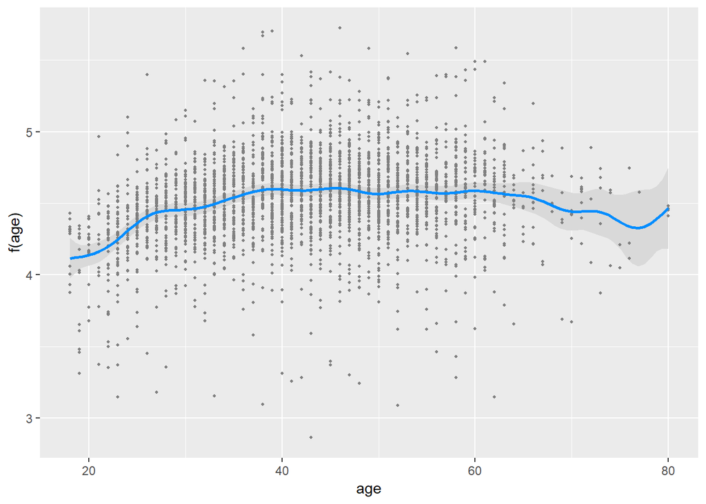

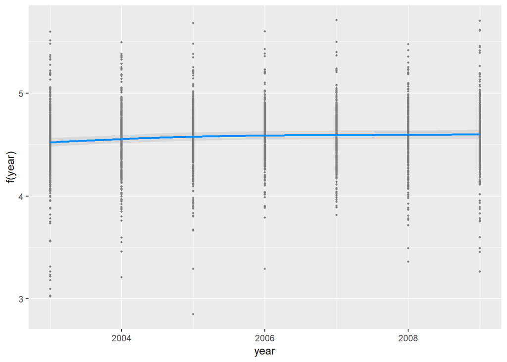

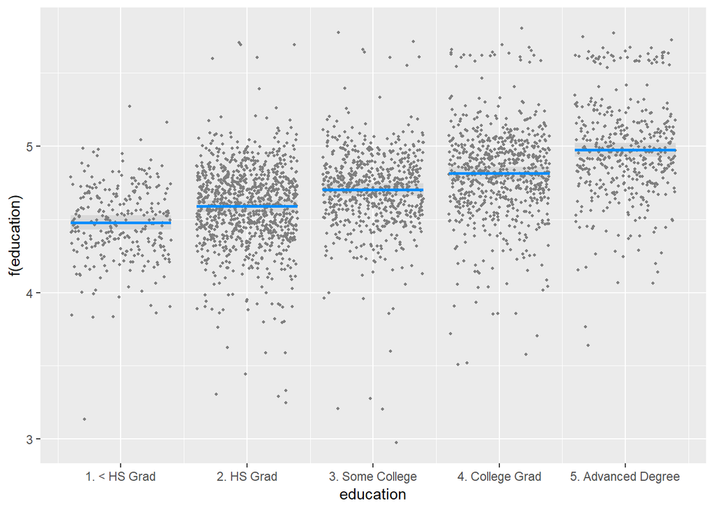

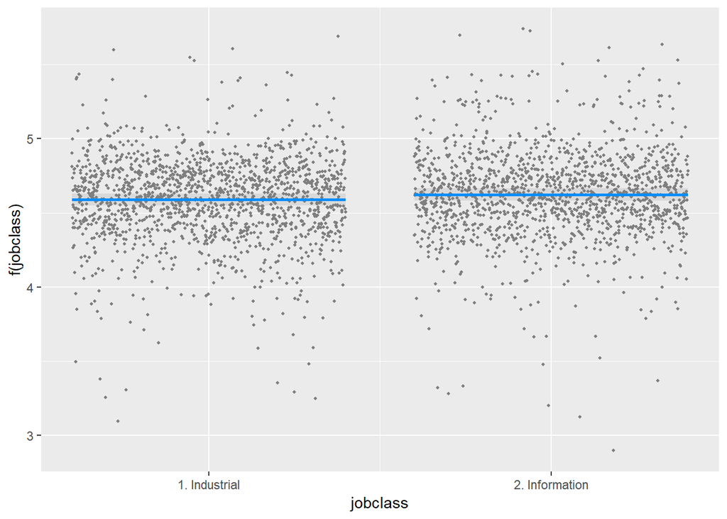

- **age**: It is clearly different from the regression line in *Question 2* where we only fit a linear model. Here, the regression spline allows for the up and down changes during different period of age. For example, the visreg plot shown in **Question 2** illustrates that the wage increase as people get older. However, with regression spline, we can see a drop of wage from around 65 until 76, after that the wage increase again (probably due to pension).
- **year**: We fit a spline with 4 knots for year but looking at the plot, we barely observe any wiggle. The plot displays an upward trend of wage over time and it is reasonable to see this trend because of growing economic. Thus, we may not need to add splines for the **year** variable.
- **education**: The plot shows the same pattern as in *Question 1* - The higher the education, the higher the wage.
- **jobclass**: Male workers whose type of job is **Information** tend to earn higher wage than workers whose type of job is **Industrial**.

# Question 5

```
##
## Family: gaussian
## Link function: identity
##
## Formula:
## log(wage) ~ s(age, k = 20) + year + education + jobclass
##
## Parametric coefficients:
##                              Estimate Std. Error t value Pr(>|t|)
## (Intercept)                 -19.96678    5.30521   -3.76  0.00017 ***
## year                          0.01215    0.00264    4.59  4.5e-06 ***
## education2. HS Grad           0.11356    0.02021    5.62  2.1e-08 ***
## education3. Some College      0.22793    0.02138   10.66  < 2e-16 ***
## education4. College Grad      0.33835    0.02143   15.79  < 2e-16 ***
## education5. Advanced Degree   0.49861    0.02352   21.20  < 2e-16 ***
## jobclass2. Information        0.03512    0.01126    3.12  0.00183 **
## ---
## Signif. codes:  0 '***' 0 '**' 0 '*' 0 '.' 0 ' ' 1
##
## Approximate significance of smooth terms:
##         edf Ref.df    F p-value
## s(age) 6.09   7.62 43.2  <2e-16 ***
## ---
## Signif. codes:  0 '***' 0 '**' 0 '*' 0 '.' 0 ' ' 1
##
## R-sq.(adj) =  0.309   Deviance explained = 31.2%
## -REML = 599.65  Scale est. = 0.085452  n = 3000
```

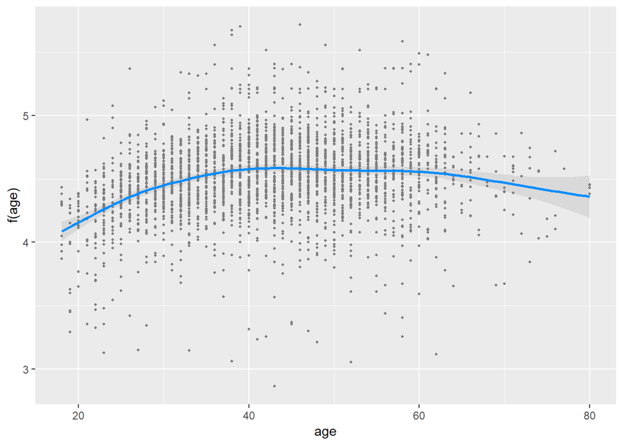

The regression line is much smoother here since penalizing knots is allowed when fitting the model. We now observe three period of changes in wage: - The wage increases from **18 to 40 years old** - Then the wage barely changes until a worker reaches **60 years old** - From **60 years old** onward, the wage declines gradually

The confidence interval is much wider toward the end of the line (from 65 to 80 years old). This is because we only have a few observations for these ages, so the model is more uncertain in predicting the wage.

# Question 6

```
##
## Family: gaussian
## Link function: identity
##
## Formula:
## log(wage) ~ year + education + jobclass + te(age, k = 20, by = jobclass)
##
## Parametric coefficients:
##                              Estimate Std. Error t value Pr(>|t|)
## (Intercept)                 -19.95652    5.30445   -3.76  0.00017 ***
## year                          0.01214    0.00264    4.59  4.6e-06 ***
## education2. HS Grad           0.11282    0.02022    5.58  2.6e-08 ***
## education3. Some College      0.22789    0.02139   10.66  < 2e-16 ***
## education4. College Grad      0.33865    0.02145   15.79  < 2e-16 ***
## education5. Advanced Degree   0.49972    0.02353   21.24  < 2e-16 ***
## jobclass2. Information        0.03534    0.01126    3.14  0.00172 **
## ---
## Signif. codes:  0 '***' 0 '**' 0 '*' 0 '.' 0 ' ' 1
##
## Approximate significance of smooth terms:
##                                 edf Ref.df    F p-value
## te(age):jobclass1. Industrial  4.80   6.03 35.4  <2e-16 ***
## te(age):jobclass2. Information 4.41   5.57 20.6  <2e-16 ***
## ---
## Signif. codes:  0 '***' 0 '**' 0 '*' 0 '.' 0 ' ' 1
##
## R-sq.(adj) =  0.309   Deviance explained = 31.3%
## GCV = 0.085924  Scale est. = 0.085459  n = 3000
```

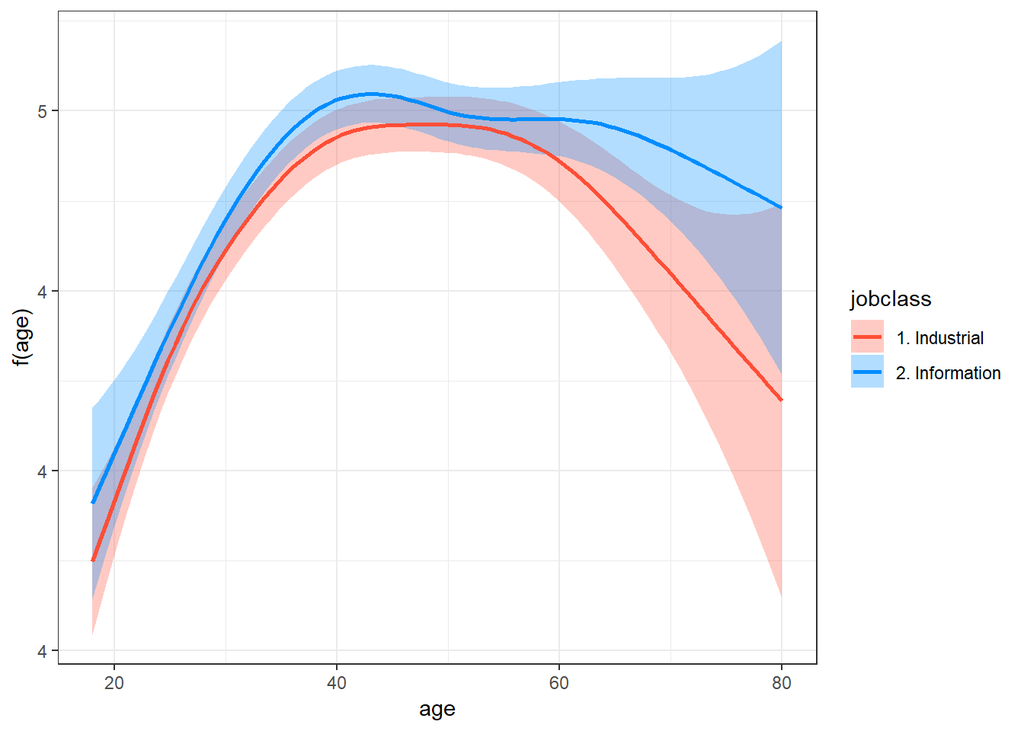

# Question 7

```
## Analysis of Deviance Table
##
## Model 1: log(wage) ~ s(age, k = 20) + year + education + jobclass
## Model 2: log(wage) ~ year + education + jobclass + te(age, k = 20, by = jobclass)
##   Resid. Df Resid. Dev   Df Deviance   F Pr(>F)
## 1      2985        255
## 2      2981        255 3.57    0.245 0.8   0.51
```

Based on the F test, we cannot reject the null hypothesis that the interaction is insignificant. Thus, the model is better without the interaction. As a result, we will choose the penalize regression spline with 20 knots for age. Next, we can test whether this model contains any non-linearity.

```
## Analysis of Deviance Table
##
## Model 1: log(wage) ~ s(age, k = 20) + year + education + jobclass
## Model 2: log(wage) ~ age + year + education + jobclass
##   Resid. Df Resid. Dev    Df Deviance    F Pr(>F)
## 1      2985        255
## 2      2992        272 -7.03    -17.2 28.7 <2e-16 ***
## ---
## Signif. codes:  0 '***' 0 '**' 0 '*' 0 '.' 0 ' ' 1
```

Since p-value is much smaller than 0.05, we can reject the null hypothesis of linearity and conclude that there is non-linear term existing in the model. And the non-linear term is `age`.

# Question 8

- For an *Industrial* job in *2009*, a *20-year-old* worker with *HS Grad* education is predicted to earn 66 thousands of dollars.
- For an *Industrial* job in *2009*, a *60-year-old* worker with *HS Grad* education is predicted to earn 99 thousands of dollars.